# A3: SPL Library Checkouts

### Introduction

Here I am doing an analysis on the checkout trends at the Seattle Public Libraries. This aims to better understand the checkout patterns that users have for the library. The dataset comes from the Seattle Public Library. It includes both physical and electronic checkouts that have come from their recorded database. The parameters of the dataset include various fields such as CheckoutTyper, Material Type, CheckoutYear, CheckoutMonth, Title, Creator, and Subjects. I am using a smaller dataset that only includes data from 2017-2023 and items that have been checked out at least 10 times a month. This data is collected to allow both the public and the agency to monitor what is being checked out and to help them better the selection of items for its users. The checkout data doesn’t include any information on who checked out the item and so it doens’t impact people personally. Some of the issues with this dataset come from its messiness and non-uniformity for the recorded data like publishing date.

### Summary Information

Looking at the summary statistics of the dataset that I am working with, I found that the maximum number of checkouts in a given month was 1 (January). January might be a popular time for people to checkout items at Seattle Public Library as people make resolutions to read more. The month of January had a total number of 76310. In addition, I looked into which title was checked out the most and the title of this item is called *So You Want to Talk about Race (Unabridged)*. It was checked out a total of 4903 times during this time period. Knowing this helps to give Seattle Public Library an idea of the popular titles and trying to have an adequate number to be checked out if needed. Furthermore, as other forms of media are increasingly being used, I wanted to see how many audiobooks were checked out during this time. The number came out to be 147629. Overall, these varibales give a general overview of how users checkout at the Seattle Public Library and what they are interested in.

### Checkout By Material Over Time

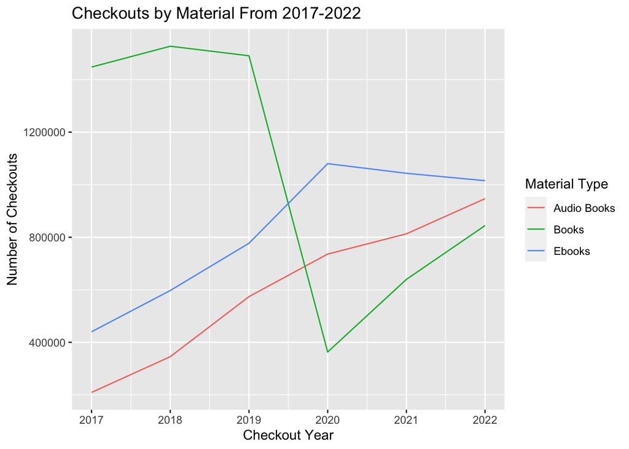

From this line graph, we can see that from 2017 until about 2019, books were the majority of items being checked out at the library for items checked out more than 10 times in a month. From then on, audio books and ebooks began to rise in numbers. This might be due to COVID-19 chnaging the way we interact with the library. Slowly, books have started to rise in numbers as libraries began to open up to the public again.

### Second Trends Over Time Chart

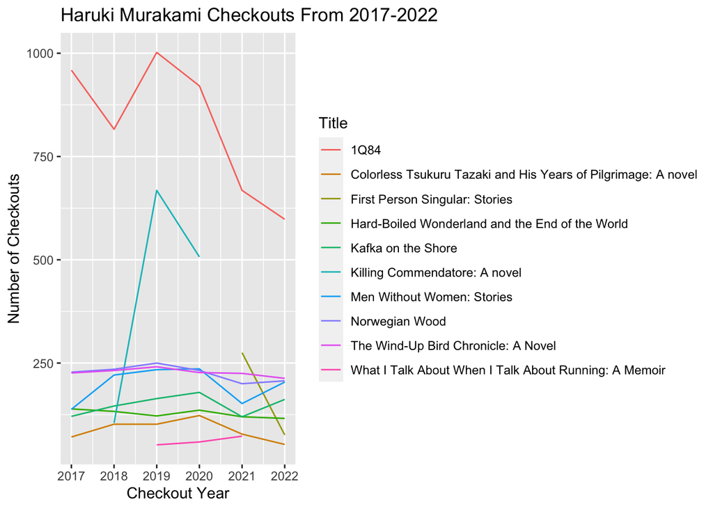

For this graph, I decided to look into the checkout patterns of books by Haruki Murakami. I enjoy the work from the author and wanted to know how users at Seattle Public Libaries were checking out his books. He has many books so I stuck with books that had been checked out at least 50 times in a given year. This made the graph more readable with less varibales to take into account. Here, *1Q84* is his most popular book to be checked out at Seattle Public Library. Over time, it has gradually went down numbers. *Killing Commendatore: A novel* also had a high number of checkouts and decreased after about 2019.

### Your Choice

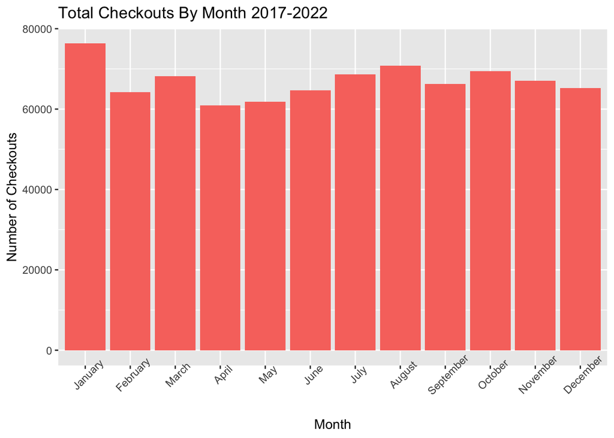

This bar chart looks at the total number of checkouts each month from the years 2017-2022. From this, it can be seen that January has the highest number of checkouts. This may be due to people wanting to read more from New Year’s resolutions. The next highest happenes in August and this might be from students heading back to school and needing certain books for their education.